# EDA_FA2_KHAFAJI

# Analysing the Cytof data set

## 1

Loading and Pivoting

We will be manipulating the “Cytof” dataset into something that is easier to run an analysis on.

To do this, we will have to use the pivot longer function on.

```r
cytof_data <- read.csv("../cytof_one_experiment.csv")

cytof_pivot <- cytof_data %>%
  pivot_longer(cols = colnames(cytof_data), names_to = 'protein_identity', values_to = 'protein_level')


head(cytof_pivot)
```

```
## # A tibble: 6 × 2
##   protein_identity protein_level
##   <chr>                    <dbl>
## 1 NKp30                    0.188
## 2 KIR3DL1                  3.62
## 3 NKp44                   -0.561
## 4 KIR2DL1                 -0.294
## 5 GranzymeB                2.48
## 6 CXCR6                   -0.145
```

## 2.

Let’s find the median protein level and the median absolute deviation for each protein identity.

```r
cytof_median_summarized <- cytof_pivot %>%
  group_by(protein_identity) %>%
  summarise(median_protein_level = median(protein_level), median_absolute_deviation = mad(protein_level))

cytof_median_summarized
```

```
## # A tibble: 35 × 3
##    protein_identity median_protein_level median_absolute_deviation
##    <chr>                           <dbl>                     <dbl>
##  1 CD107a                        -0.122                      0.609
##  2 CD16                           5.12                       0.874
##  3 CD161                          0.726                      1.69
##  4 CD2                            3.95                       1.68
##  5 CD4                           -0.204                      0.395
##  6 CD56                           5.71                       0.998
##  7 CD57                           3.07                       1.99
##  8 CD69                           4.59                       1.02
##  9 CD8                            2.40                       2.29
## 10 CXCR6                         -0.0581                     0.727
## # ℹ 25 more rows
```

## 3.

Plotting median absolute deviation vs median protein level, also known as an spreadlocation plot.

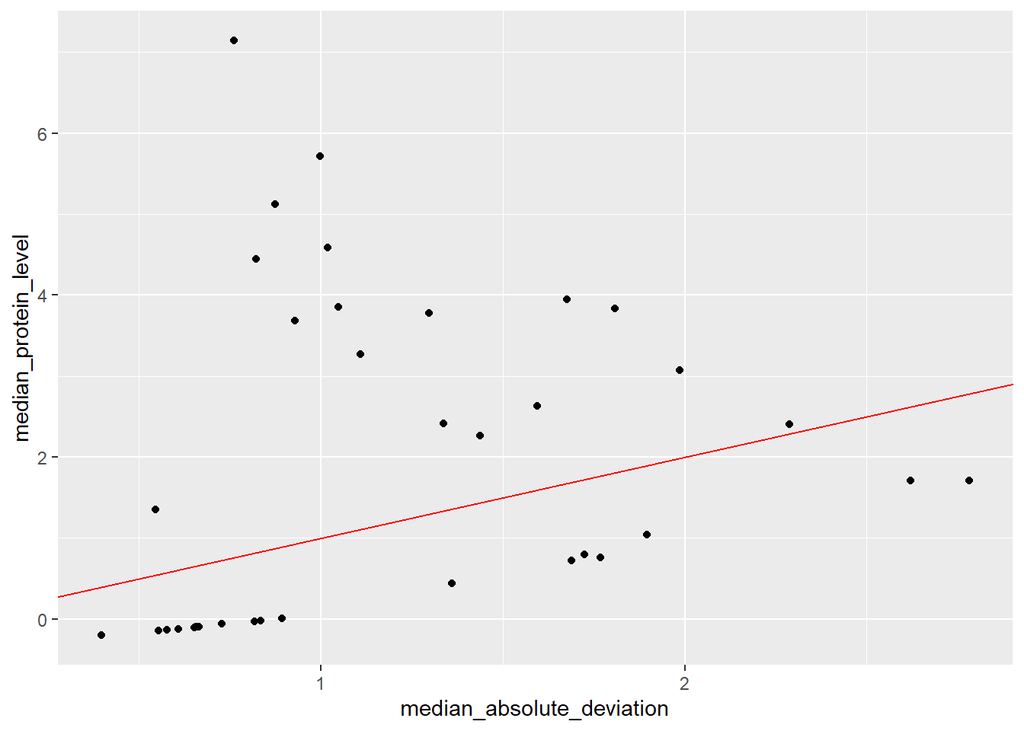

```r
ggplot(data = cytof_median_summarized) +
  geom_point(mapping = aes(x=median_absolute_deviation, y=median_protein_level))+
  geom_abline(slope = 1, intercept = 0, color = "red")
```

The plot shows that there is little to no overarching trend between the median absolute deviation and the median protein levels. However, we can see little clusters form, which indicate that these proteins have similar levels of importance with regards to physiology.

There are some proteins that have a relatively high median protein level, but have a deviation smaller than 1, which would indicate that these proteins are important to the human physiology.

# 4. Practicing Pivoting

Let’s load the practice data example_gymnastics_2 from dcldata:

```r
head(example_gymnastics_2)
```

```
## # A tibble: 3 × 5
##   country       vault_2012 floor_2012 vault_2016 floor_2016
##   <chr>              <dbl>      <dbl>      <dbl>      <dbl>
## 1 United States       48.1       45.4       46.9       46.0
## 2 Russia              46.4       41.6       45.7       42.0
## 3 China               44.3       40.8       44.3       42.1
```

Let’s pivot this longer, creating columns for country, event, year, and score.

```r
gymnastics_df <- example_gymnastics_2 %>%
  pivot_longer(cols = -c("country"), names_to = 'event_year', values_to = 'score') %>%
  separate_wider_delim(event_year, '_', names = c('event', 'year') )

gymnastics_df
```

```
## # A tibble: 12 × 4
##    country       event year  score
##    <chr>         <chr> <chr> <dbl>
##  1 United States vault 2012   48.1
##  2 United States floor 2012   45.4
##  3 United States vault 2016   46.9
##  4 United States floor 2016   46.0
##  5 Russia        vault 2012   46.4
##  6 Russia        floor 2012   41.6
##  7 Russia        vault 2016   45.7
##  8 Russia        floor 2016   42.0
##  9 China         vault 2012   44.3
## 10 China         floor 2012   40.8
## 11 China         vault 2016   44.3
## 12 China         floor 2016   42.1
```

We have successfully created a better table for the data, creating columns for their country, the event, the year, and the respective score. This way, we can analyze the data better.